# Extra-Marital Conduct: Evolution and Nature of Opinion

# Introduction

There is no dearth of research on American’s changing attitudes towards marriage, its primacy as a way of life, and its exclusivity. Approximately four-in-ten Americans say that the present institution of marriage is becoming obsolete (Taylor 2010). According to the same Pew Research 2010 study, 72% of all adults in America were married in 1960. By 2008, this percentage had dropped to 52%. From this apparent decline in marriage, Americans are slowly becoming more accepting of open relationships, consensual non-monogamy (CNM) practices, and the like. Nearly half of the population of Americans would consider an open relationship, though fewer than 4% actually claim to be in one (Avvo 2017). Notwithstanding, nearly 22% of married men and 14% of married women admit to having an affair at least once during their marriages (Johnson et al. 2017).

## Research Questions

Table 1: Research Questions

| # | Research.Question | Years |
| --- | --- | --- |
| 1 | Is there a linear trend in the proportion of non-traditional opinion over time, controlling for gender? | 1973-2016 |
| 2 | Is there an association between opinion w.r.t. extra marital conduct and region? | 2012-2016 |
| 3 | Is there an association between opinion w.r.t. extra marital conduct and class? | 2012-2016 |
| 4 | Is there an association between opinion w.r.t. extra marital conduct and gender? | 2012-2016 |
| 5 | Is there an association between opinion w.r.t. extra marital conduct and age? | 2012-2016 |
| 6 | Is there an association between opinion w.r.t. extra marital conduct and marital status? | 2012-2016 |

## Document Organization

The **methods** section describes the data, the sampling techniques, data preprocessing, and introduces the methods, descriptive and inferential techniques used in the analyses. Hypotheses are offered, analyzed and tested in the **results** section. The **discussion** section describes the significance of the findings vis-a-vis currently available research. Lastly, the **conclusion** synthesizes the key points.

# Methods

## Data

The General Social Survey (GSS), a project of the NORC at the University of Chicago, provided the data upon which this report is based. Formerly known as the National Opinion Research Center, “NORC at the University of Chicago is an objective non-partisan research institution that delivers reliable data and rigorous analysis to guide critical programmatic, business, and policy decisions” (NORC 2017). Principally funded by the National Science Foundation, the GSS has been monitoring evolution, complexity opinions, behaviors, and attributes of American society since 1973. Targeting the adult population, age 18 and over in the United, the data covers a diverse range of issues including national spending priorities, marijuana use, crime and punishment, race relations, quality of life, confidence in institutions, and sexual behavior.

### Data Sampling Strategy

The GSS employed a multi-stage area full probability sampling strategy.

At the first stage, NORC employed the Standard Metropolitan Statistical Areas (SMSAs) or non-metropolitan counties selected in NORC’s Master Sample, as the Primary Sampling Unit (PSU). These were further subdivided into three categories. Category 1, representing 56% of the US population, comprised of the nations largest metropolitan areas or Consolidated Statistical Areas (CSAs) with a population of at least 1,543,728 (0.5 percent of the 2010 Census U.S. population). The second category, covering 35% of the US population, included Core Based Statistical Areas and CSAs with at least 8 tracts that are predominantly street-style addresses. The third category spanned 9% of the US population and consisted of small counties with at most 8 tracts. Minimum size for tracts were defined as 300 respondents.

Similarly, the second stage sampling was conducted in three categories. Category 1 comprised 216 type A tracts (city addresses) and 8 block-groups within type B (rural) tracts. Category 2, consisted of 8 segments per first-stage selection resulted in 480 segments in the 2010 National Sample Design, but GSS used only 120 of them. For category 3 first-stage selections, the 2010 National Sample Design only selected 5 segments per first-stage selection, but GSS used 4 and one half of them for a total of 56 segments.

The sampling strategy employed by GSS was designed to give each household an equal probability of being included in the sample. For each household selected, sampling procedures were undertaken to ensure that each individual in that household had an equal probability of being interviewed.

### Data Sampling Bias

The GSS samples closely resemble distributions reported in the Census and other authoritative sources. However, survey non-response, sampling variation, and various other factors have introduced potential sources of bias and resulted in variance from Census distributions on some variables. For instance all full-probability samples under-represent males and block quota samples under-represented men in full-time employment. Weights were designed (and should be employed when using GSS 2004 or later), to assure proper representation of non-response sub-samples, and other factors. For a full discussion of distributional variation due to non-response, one should refer to the GSS Methodological Reports in the help and resources section at https://gssdataexplorer.norc.org/,

This full probability design was acknowledged by the National Science Foundation to be superior to simple random sampling, and **generalizable** to the population of adult citizens in America. Consisting of over 60,000 individual responses, spanning over 40 years, the GSS data remains one of the nations treasures, providing data for inference about American society to researchers, academics, students, politicians, and opinion makers. Yet, as respondents were randomly selected (not assigned), one is careful to limit inferences to **association, and not causation.** That said, the extent to which results of a research question can be generalized to the population will require that the inference conditions are met, specifically the proportion success/failure condition. As such, the question of “generalize-ability” will need to be re-addressed independently for each research question.

### Data Variables

The following table lists the variables extracted from the GSS data.

Table 2: Study Variables

| # | Variable | Type |
| --- | --- | --- |
| 1 | xmarsex: Sex with person other than spouse | Response |
| 2 | age: Age of respondent | Explanatory / Controlling |
| 3 | class: Subjective class identification | Explanatory |
| 4 | marital: Marital status | Explanatory |
| 5 | region: Region of interview | Explanatory |
| 6 | sex: Respondent’s sex | Explanatory |
| 7 | year: GSS year for this respondent | Explanatory |

### Data Preprocessing

The GSS variables were extracted for years 1973 thru 2016 and the following variables were created.

**Opinion**: Two factor variable:  
* Traditional: Always wrong and almost always wrong  
* Non-Traditional: Sometimes wrong and not wrong at all

**Age Group**: Four factor variable:  
* 18-24 * 25-44  
* 45-64 * 65+

**Region**: Five factor variable:  
* Northeast: Comprised of responses from the New England and Mid Atlantic regions  
* Midwest: Comprised of responses from the East Central and West Central regions  
* South: Consisting of responses from the South Atlantic and East and West South Central regions  
* Mountain  
* Pacific

Responses with “NAs”, “Don’t Know”, and other non-response values for the GSS variables in scope, were filtered from the data set.

## Data Analysis

This study involved univariate, bivariate and multivariate statistics.

Univariate analyses (exploratory data analysis) provided the descriptive and inferential statistics on a single-variable basis. Since all variables were categorical, frequencies and proportions were revealed using frequency distribution (contingency) tables and bar charts. Confidence intervals for the true population proportion for each value of each categorical variable were also computed.

The bivariate analyses examined, tested, and reported the existence, strength and direction of associations between opinion and a single explanatory variable. **Hypothesis driven** chi-square tests of independence were used to determine whether an **association was extant**. For this analysis, confidence intervals didn’t apply. To evaluate the **strength and direction** of an association, **hypothesis tests** for the difference in two proportions were conducted pairwise for each level of the explanatory variable, to determine the probability of encountering a difference as extreme as that observed, assuming a null hypothesis of zero difference. If the probability was less than $\alpha = 0.05$, the tolerable probability of a type I error, the null hypothesis was rejected in favor of the alternative hypothesis of a difference in proportions. In addition, **confidence intervals** for the difference in the proportions were computed for the difference in the proportions, given the null hypothesis. If the interval didn’t include zero difference, the null hypothesis of equal proportions was rejected. Note: the degree to which both approaches agree was addressed when both comparing two categorical levels, such as gender and opinion. For multiple two-proportion tests, some comparisons yielded significant differences, others did not. Comparing multiple p-values against a single chi-square statistic would not be appropriate in this case.

Similarly a hypothesis driven chi-square trend test, also known as the Cochran-Armitage test for trend, was conducted to determine whether a trend was extant. Based upon a chi-square statistic, a p-value is computed and an inference is made as was described above. This has one degree of freedom because the linear scoring of the proportions by year means that when one expected value is given all the others are fixed. This statistical technique is explained in further detail below.

### Data Analysis Methodology

The following hypothesis driven approach was used for the univariate and multivariate analyses.  
1. Plot the data  
2. State Hypotheses  
3. Check Parametric Inference Conditions  
4. Determine the necessary minimum sample size (Single Proportion Inference) 5. Select appropriate statistical method / test statistic  
6. Compute the p-value, confidence intervals  
7. Interpret and report results.

#### Plot The Data

For the *univariate* analyses, data tables and bar plots illuminate the frequencies and proportions of responses for each level of the categorical variable. Histograms graphically depict the distribution of quantitative variables in the sample. For the *multivariate* analysis, data tables and bar plots show the proportion of opinion at each level of the explanatory categorical variable. The effect of a quantitative variable, such as the number of hours watching television, on opinion is graphically depicted using box-plots.

#### State Hypotheses

Four types of hypotheses statements were used in this study.  
1. Single proportion  
2. Difference of two proportions  
3. Association 4. Trend in proportions

**Single Proportion**  
This type of hypothesis statement, used in the univariate analysis of categorical variables, was used to estimate the true population parameter and as follows:  
$H_0$ $p - \hat{p} = 0$  
$H_a$ $p - \hat{p} \neq 0$  
where:  
$p$ is the true population proportion  
$\hat{p}$ is the observed sample proportion

**Differences in two Proportions**  
This type of hypothesis statement was used in the multivariate analysis to determine the true difference in the proportion of non-traditional opinion for two populations and took the following form.  
$H_0$ $p_1 - p_2 = 0$  
$H_a$ $p_1 - p_2 \neq 0$ Two sided, or  
$H_a$ $p_1 < p_2$ One sided, or  
$H_a$ $p_1 > p_2$ One sided  
where:  
$p_1$ is the proportion of non-tradition opinion in the first population of interest  
$p_2$ is the proportion of non-tradition opinion in the second population of interest

**Association**  
This type of hypothesis statement was used to ascertain the association between opinion and categorical explanatory variables and took the following form.  
$H_0$ $p_1 = p_{10}, p_2 = p_{20}, ...p_k = p_{k0}$  
$H_a$ At least one proportion is different from the others.  
where:  
$k$ is the number of response categories  
$p_k$ is the *observed* proportion for the $k^{th}$ response category  
$p_{k0}$ is the *expected* proportion for the $k^{th}$ response category

#### Inference Conditions

Statistical inferences were derived from parametric statistics and the central limit theorem, whereby the former assumes that sample data comes from a population distribution with a fixed set of parameters, and the later assumes that the sampling distribution for the parameter of interest is normal. The parameters for inferences for proportions are $N(\mu, \sigma^2)$, where $\mu$ is the population proportion parameter $\hat{p}$ and $\sigma^2$ is the variation of of the population proportion parameter. The degree to which the distribution can be considered normal depends upon the type of inference being undertaken.

**Inference for Single Proportion**  
These conditions applied to the univariate analyses of the categorical variables. One can assume that the sampling distribution of the proportion $\hat{p}$ is normal if:  
1. **Independence:** The sample observations are independent. Since all samples were obtained through complex random sampling, and the sample consists of less than 10% of the adult U.S. population, independence was assumed for all statistical tests.  
2. **Success/Failure:** There must be a minimum of ten successes and failures in the sample.

**Inference for Difference of Two Proportions**  
These conditions applied to the multivariate analyses of the difference in the proportion of non-traditional opinion in two populations. One can assume that the sampling distribution of the *difference* of two proportions $p1 - p2$ is normal if:  
1. **Within Sample Independence:** Each sample meets the independence criteria, specifically, samples were obtained from a random sampling process and consists of less than 10% of the adult U.S. population.  
2. **Cross-Sample Independence:** Both samples are independent from each other.

**Inference for Association and Trend (Chi-square independence & Cochran-Armitage test)**  
These conditions applied to the multivariate analyses of the association between opinion and the various explanatory variables. The following three conditions were confirmed for all association tests.  
1. **Independence:** Each case that contributes a count to the table must be independent of all the other cases in the table.  
2. **Sample Size:** Each particular scenario (i.e. cell count) must have at least 5 *expected* cases.  
3. **Degrees of Freedom:** The contingency table must be associated with a chi-square distribution with two or more degrees of freedom. This requirement is relaxed for trend tests.

#### Minimum Sample Size

Minimum required sample sizes were computed during the univariate analysis to confirm that the sample parameters were within a 5% margin of error of the true population parameters. The minimum sample size for estimating the population proportion was computed as follows:

$$N_{min} = \frac{p_l(1-p_l)}{(\frac{me}{z^*})^2}$$
where $p_l$ is the sample proportion for the categorical variable at level $l$ $me$ is the margin of error $z^*$ is the critical value on the z-distribution for the designated margin of error

#### Statistical Methods

Four types of statistical methods were used to evaluate the hypotheses statements:  
1. Single proportion z-tests for estimating the true population parameter  
2. Two-proportion z-tests for the difference in proportions with confidence intervals  
3. Chi-square test for independence  
4. Cochran-Armitage test for trends in proportions

##### Single Proportion z-test

Single proportion z-tests were conducted to used to construct confidence intervals for a population proportion, and is computed as follows:
$$\hat{p} \pm z^* * SE$$
where:
$\hat{p}$ is the point estimate for the population proportion, e.g. the sample proportion
$Z^*$ is the $z_{\alpha/2}$ critical value for a two sided z-distribution at a 95% confidence level $\approx 1.96$

The standard error $SE$ is computed as follows:
$$SE= \sqrt{\frac{\hat{p}(1-\hat{p})}{n}}$$
where:
$n$ is the sample size
$\hat{p}$ is the the sample proportion of interest

##### Two proportion z-test

To evaluate hypotheses w.r.t. the difference in two proportions, z-tests were conducted using the *pooled* proportions for the standard error calculation. Pooled proportions, $\hat{p}$, were calculated as follows:

$$\hat{p} = \frac{\hat{p_1}n_1 + \hat{p_2}n_2}{n_1 + n_2}$$
where:
$n1$ is the sample size of the sample 1
$n2$ is the sample size of the sample 1
$p1$ is the the proportion of of from sample 1
$p2$ is the the proportion of of from sample 2

Given the pooled proportion, the *pooled* standard error, $SE_{pooled}$, for the difference in proportions was calculated as follows:
$$SE_{pooled} = \sqrt{\frac{\hat{p}(1-\hat{p})}{n_1} + \frac{\hat{p}(1-\hat{p})}{n_2}}$$
where:
$\hat{p}$ is the pooled proportion calculated above
$n1$ is the sample size of the sample 1
$n2$ is the sample size of the sample 2

Lastly, the z-statistic under the null hypothesis of equal proportions was calculated as follows:
$$Z = \frac{(\hat{p_1} - \hat{p_2}) - 0}{SE_{pooled}}$$
The z-statistic was used to calculate a p-value by comparing the value of the statistic for each random variable $X$ to a *standard normal* distribution ($X \sim N(\mu = 0, \sigma^2 = 1)$. The selected level of confidence for all statistical tests was 95% ($\alpha = 0.05$). If the p-value was less than or equal to $\alpha$, the null hypothesis was rejected. Otherwise, the null hypothesis was not rejected. The p-value for a Gaussian distribution was obtained using the R statistical software package and is computed as follows:
$$p(x;\mu, \sigma^2) = \frac{1}{\sqrt{2\pi} * \sigma} * exp(-\frac{(x-\mu)^2}{2\sigma^2})$$
where:
$x$ = random variable
$\mu$ = mean of random variable $x$
$\sigma$ = standard deviation of a random variable $x$

Z-tests were conducted to compute the confidence interval for the difference in two proportions. The 95% confidence intervals for the differences in two proportions were computed as follows:
$$C = (\hat{p_1} - \hat{p_2}) \pm Z^* * SE$$
where:
$\hat{p_1}$ is the the proportion of interest from sample 1
$\hat{p_2}$ is the the proportion of interest from sample 1
$Z^*$ is the $z_{\alpha/2}$ critical value for a two sided z-distribution at a 95% confidence level $\approx 1.96$

The standard error $SE$ is computed as follows:
$$SE= \sqrt{\frac{\hat{p_1}(1-\hat{p_1})}{n_1} + \frac{\hat{p_2}(1-\hat{p_2})}{n_2}}$$
where:
$n1$ is the sample size of the sample 1
$n2$ is the sample size of the sample 1
$\hat{p_1}$ is the the proportion of of from sample 1
$\hat{p_2}$ is the the proportion of of from sample 2

**Relative risk ratio** was calculated to estimate the probability of encountering an opinion (traditional or non-traditional) for two levels of an explanatory variable. Relative risk was computed as follows:
$$RR = \frac{\frac{a}{a+b}}{\frac{c}{c+d}}$$
where:
$a$ is the probability of having opinion x, given condition 1
$b$ is the probability of having opinion y, given condition 1
$c$ is the probability of having opinion x, given condition 2
$d$ is the probability of having opinion y, given condition 2

**Multiple Two-Proportion Tests**  
Lastly, multiple difference in proportion tests were often conducted to compare the differences across several levels of a categorical explanatory variable. Since the chance of rare events increases with multiple tests, the likelihood of incorrectly rejecting the null hypothesis also increases. To compensate for that increase the **Bonferroni correction** was applied to the hypothesis tests, changing the significance level to $\alpha / m$, where $\alpha$ is the level of significance and $m$ is the number of hypothesis tests. The number of hypothesis tests $m = k(k-1)/2$, where $k$ is the number of groups being tested. The confidence interval was also adjusted, changing the overall confidence level from $1 - \alpha$ to $1 - \alpha/m$. The Marascuilo* method of multiple comparisons was used to test all combinations of groups.

##### Chi-square test of independence.

To evaluate the association between opinion and the categorical explanatory variables, Pearson’s chi-square $X^2$ test of independence was employed to compute the probability of observing differences in proportions as extreme as the differences observed, assuming the null hypothesis that observed counts $O$, and expected counts $E$ are equal. The expected counts are computed as follows:

$E_{(i,j)} = \frac{0T_i * 0T_j}{0T}$ where:  
$E_{(i,j)}$ is a contingency table of expected counts with rows $i$ and columns $j$.  
$0T_i$ is the total for row $i$ from the observed contingency table.  
$0T_j$ is the total for column $j$ from the observed contingency table.  
$0T$ is total counts for the observed contingency table.

Given the observed and expected counts, the $X^2$ test statistic is the normalized sum of squared deviations between observed and expected counts and is computed as follows:
$$X^2 = \displaystyle\sum_{i=1}^{r} \displaystyle\sum_{j=1}^{c} \frac{(O_{i,j} - E_{i,j})^2}{E_{i,j}}$$
where:

$X^2$ is Pearson’s cumulative test statistic.  
$O_{i,j}$ is the frequency or count from row $i$ and column $j$ of the observed contingency table  
$E_{i,j}$ is the frequency or count from row $i$ and column $j$ of the expected contingency table  
$r$ is the number of rows in the observed (and expected) contingency tables  
$c$ is the number of columns in the observed (and expected) contingency tables

##### Cochran-Armitage Test

The Cochran-Armitage test for trends in proportions is a more powerful version of the chi-square test for independence that takes into account a linear scoring for an ordinal categorical variable. Assume there are $k$ independent binomial variates $y_i$, with sample sizes $n_i$, at ordinal explanatory categorical levels $x_i$, for $i = 1, 2, ..., k$ where $x_1 < x_2 < ... < x_k$, let:

$N = \displaystyle\sum_{i=1}^{k} n_i$  
$\hat{p} = \frac{1}{N}\displaystyle\sum_{i=1}^{k} y_i$  
$\hat{q} = 1 - \hat{p}$  
$\bar{x} = \frac{1}{N}\displaystyle\sum_{i=1}^{k} n_ix_1$

Th uncorrected test statistic is:
$$z = \frac{\displaystyle\sum_{i=1}^{k} y_i(x_i-\bar{x})}{\sqrt{}\hat{q}\hat{p}[\displaystyle\sum_{i=1}^{k} n_i(x_i-\bar{x})^2]}$$

##### Compute p-Value and Confidence Intervals

As indicated above, both p-value and confidence interval approaches were used for two proportion hypothesis tests.

#### Interpret and report results

For the confidence interval approach, the null hypotheses were evaluated as follows:  
* Confidence interval does not include zero, the null hypothesis is **rejected**. in favor of the alternative hypothesis.  
* Confidence interval includes zero, the null hypothesis is **not rejected**.

## System and Environment

This analysis was implemented using the 64 bit version of the R Programming Language, version 3.4.1. (The R Foundation 2015) within the R. Studio Version 1.1.330 (Rstudio Team 2016) development environment on a Windows x64-based laptop powered by an Intel Core i7-3610QM CPU @ 2.30GHz, 2301 MHz processor with 4 Cores, 8 Logical Processors, and 16.0 GB of installed memory, running the Microsoft Windows 10 Home operating system, version 10.0.14393 Build 14393. Statistical analysis functionality (chisq.test, prop.trend.test) was provided by the Stats package (R Core Team 2013). Report writing and generation packages included knitr (Xie 2013), and kfigr (Koohafkan 2015). Data management functionality was provided by the dplyr [Wickham2015a], reshape2 (Rcpp 2016), xtable (Dahl and Scott 2016) and data table (Dowle 2016) packages. Graphics and data visualization were powered by the ggplot2 (Wickham 2016), gridExtra (Baptiste Auguie 2016), and the stargazer (Hlavac et al. 2015) packages.

## Reproducibility

This report, along with the software and data are available as part of the xms package which is available for forking at https://github.com/DataScienceSalon/xms. Alternatively, the package can be installed from github using devtools as follows:

```r
devtools::install_github("DataScienceSalon/xms")
```

# Results

## Exploratory Data Analysis

The following descriptive and inferential statistics were computed for each study variable.  
* **N**: The counts for each level of the categorical variable  
* **Minimum N**: The minimum sample size required to ensure that the sample parameters were within a 5% margin of error (the confidence intervals) of the population parameters  
* **Proportion**: For categorical variables, the proportional responses at each level of each categorical variable  
* **Cumulative Proportions**: The cumulative proportions at each level of each categorical variable  
* **Confidence Interval**: The 95% confidence interval for the population parameter  
Furthermore, the conditions for inference were checked in order to characterize the degree to which the samples were representative of the population proportions.

### Opinion

As shown in Table 3, there were a total of 37,582 observations, with 33,717, and 3,865 traditional and non-traditional opinions, respectively. Of all respondents interviewed since 1973, 90% considered extra-marital conduct to be wrong or almost always wrong.

Table 3Table 4: Descriptive and inferential statistics for the opinion variable

| Level | Minimum N | N | Proportion | Cumulative | Successes | Failures | Confidence Interval (95%) |
| --- | --- | --- | --- | --- | --- | --- | --- |
| Traditional | 142 | 33717 | 0.9 | 0.9 | 33717 | 3865 | [0.897, 0.903] |
| Non-Traditional | 142 | 3865 | 0.1 | 1.0 | 3865 | 33717 | [0.091, 0.109] |

Since the independence and success/failure criteria were met, the confidence intervals for the true population proportions were reliably computed.

### Region

As shown in Table 5, there were a total of 62,466 observations. Over 50% of respondents resided in eastern and southeastern parts of the country, 26% in the Midwest and the rest in the western states.

Table 5: Descriptive and inferential statistics for the region variable

| Level | Minimum N | N | Proportion | Cumulative | Successes | Failures | Confidence Interval (95%) |
| --- | --- | --- | --- | --- | --- | --- | --- |
| Northeast | 239 | 12033 | 0.19 | 0.19 | 12033 | 50433 | [0.183, 0.197] |
| South | 351 | 22083 | 0.35 | 0.54 | 22083 | 40383 | [0.344, 0.356] |
| Midwest | 293 | 16061 | 0.26 | 0.80 | 16061 | 46405 | [0.253, 0.267] |
| Mountain | 90 | 3882 | 0.06 | 0.86 | 3882 | 58584 | [0.053, 0.067] |
| Pacific | 179 | 8407 | 0.13 | 0.99 | 8407 | 54059 | [0.123, 0.137] |

Since the independence and success/failure criteria were met, the confidence intervals for the true population proportions were reliably computed.

### Class

As shown in Table 6, there were a total of 58,997 observations. Over 50% of respondents identified as lower class or working class. The middle class and upper class constituted 45% and 3%, respectively.

Table 6: Descriptive and inferential statistics for the class variable

| Level | Minimum N | N | Proportion | Cumulative | Successes | Failures | Confidence Interval (95%) |
| --- | --- | --- | --- | --- | --- | --- | --- |
| Lower Class | 89 | 3661 | 0.06 | 0.06 | 3661 | 55336 | [0.052, 0.068] |
| Working Class | 381 | 26948 | 0.46 | 0.52 | 26948 | 32049 | [0.454, 0.466] |
| Middle Class | 380 | 26500 | 0.45 | 0.97 | 26500 | 32497 | [0.444, 0.456] |
| Upper Class | 48 | 1888 | 0.03 | 1.00 | 1888 | 57109 | [0.022, 0.038] |

Since the independence and success/failure criteria were met, the confidence intervals for the true population proportions were reliably computed.

### Gender

As shown in Table 7, there were a total of 62,466 observations. The majority of the responses (56%) were from women.

Table 7: Descriptive and inferential statistics for the gender variable

| Level | Minimum N | N | Proportion | Cumulative | Successes | Failures | Confidence Interval (95%) |
| --- | --- | --- | --- | --- | --- | --- | --- |
| Male | 379 | 27562 | 0.44 | 0.44 | 27562 | 34904 | [0.434, 0.446] |
| Female | 379 | 34904 | 0.56 | 1.00 | 34904 | 27562 | [0.555, 0.565] |

Since the independence and success/failure criteria were met, the confidence intervals for the true population proportions were reliably computed.

### Age

As shown in Table 8, there were a total of 62,245 observations. Over 50% of the respondents were less than 45 years of age. The 25-44 age group constituted a plurality of the responses (42%), followed by the 45-64, 65+, and 15-24 age groups comprising 30%, 18% and 10%, respectively.

Table 8: Descriptive and inferential statistics for the age variable

| Level | Minimum N | N | Proportion | Cumulative | Successes | Failures | Confidence Interval (95%) |
| --- | --- | --- | --- | --- | --- | --- | --- |
| 15-24 | 141 | 6337 | 0.10 | 0.10 | 6337 | 55908 | [0.093, 0.107] |
| 25-44 | 373 | 25846 | 0.42 | 0.52 | 25846 | 36399 | [0.414, 0.426] |
| 45-64 | 325 | 18959 | 0.30 | 0.82 | 18959 | 43286 | [0.293, 0.307] |
| 65+ | 225 | 11103 | 0.18 | 1.00 | 11103 | 51142 | [0.173, 0.187] |

Since the independence and success/failure criteria were met, the confidence intervals for the true population proportions were reliably computed.

### Marital Status

As shown in Table 9, there were a total of 62,441 observations. Over 50% of the respondents were married at the time of the interview, 21% were never married, and 16% were divorced or separated.

Table 9: Descriptive and inferential statistics for the marital status variable

| Level | Minimum N | N | Proportion | Cumulative | Successes | Failures | Confidence Interval (95%) |
| --- | --- | --- | --- | --- | --- | --- | --- |
| Married | 383 | 33131 | 0.53 | 0.53 | 33131 | 29310 | [0.525, 0.535] |
| Widowed | 133 | 6000 | 0.10 | 0.63 | 6000 | 56441 | [0.092, 0.108] |
| Divorced | 171 | 7976 | 0.13 | 0.76 | 7976 | 54465 | [0.123, 0.137] |
| Separated | 51 | 2167 | 0.03 | 0.79 | 2167 | 60274 | [0.023, 0.037] |
| Never Married | 256 | 13167 | 0.21 | 1.00 | 13167 | 49274 | [0.203, 0.217] |

Since the independence and success/failure criteria were met, the confidence intervals for the true population proportions were reliably computed.

## Research Question 1: Trends in Opinion

The aim here was to determine whether a linear trend in opinion over time exists by gender. The research question is restated as follows.

> Is there a linear trend in the proportion of non-traditional opinion over time, controlling for gender?

### The Data

Figure 1 and Figure 2 show the proportion of non-traditional opinion by gender over time, for the years 1973-2011, and 2012-2016 respectively.

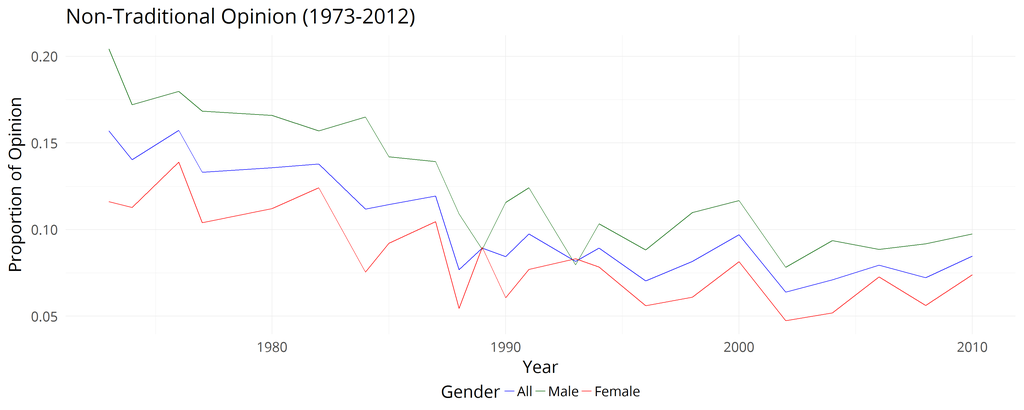

Figure 1: Proportion of non-traditional opinion 1973-2011

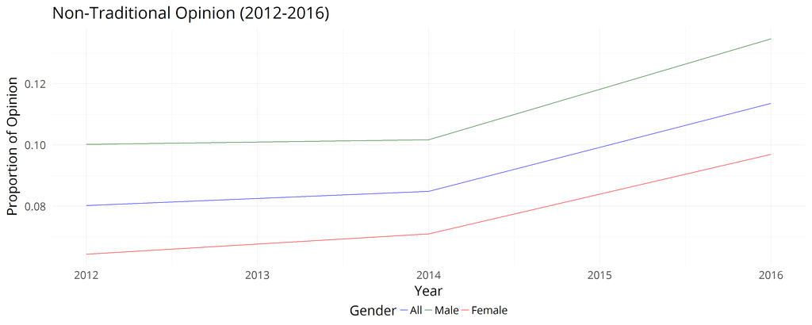

Figure 2: Proportion of non-traditional opinion 2012-2016

Table 10: Summary statistics for frequency proportion of non-traditional opinion

| Range | Gender | YearLow | YearHigh | Frequencies xMin | Frequencies xMean | Frequencies xMedian | Frequencies xMax | Proportions pMin | Proportions pMean | Proportions pMedian | Proportions pMax | PctChange |
| --- | --- | --- | --- | --- | --- | --- | --- | --- | --- | --- | --- | --- |
| 1973-2010 | All | 2002 | 1976 | 58 | 148.09 | 157 | 251 | 0.06 | 0.10 | 0.09 | 0.16 | -46.02 |
| 1973-2010 | Male | 2002 | 1973 | 36 | 79.78 | 86 | 141 | 0.08 | 0.13 | 0.12 | 0.20 | -52.26 |
| 1973-2010 | Female | 2002 | 1976 | 20 | 68.30 | 65 | 132 | 0.05 | 0.08 | 0.08 | 0.14 | -36.25 |
| 2012-2016 | All | 2012 | 2016 | 103 | 153.00 | 144 | 212 | 0.08 | 0.09 | 0.08 | 0.11 | 41.63 |
| 2012-2016 | Male | 2012 | 2016 | 57 | 82.00 | 78 | 111 | 0.10 | 0.11 | 0.10 | 0.13 | 34.47 |
| 2012-2016 | Female | 2012 | 2016 | 46 | 71.00 | 66 | 101 | 0.06 | 0.08 | 0.07 | 0.10 | 50.66 |

The data reveal two trends; the longer trend from 1973-2011, and the more recent trend from 2012-2016.

For the former Table 10 reveals that the proportion of non-traditional opinion dropped by 46% from a high of 0.16 in 1,976 to a low of 0.06 in 2,002. The most significant decline of 52% was among men over this time period from a high of 0.2 in 1,973 to a low of 0.08 in 2,002. The proportion of non-traditional opinion among women fell by 36.25%

### Hypotheses

For the 1973-2011 period, the proportion of non-traditional opinion w.r.t. extra-marital conduct appeared to exhibit a negative trend. From 2012-2016, an upward trend seemed extant. As such, the following hypotheses were tested to ascertain the degree to which a trend in the proportion of non-traditional opinion was extent, for both the 1973-2011 and 2012-2016 periods. The hypotheses were tested for males and females separately.  
* **Null Hypothesis**: There is no linear trend in non-traditional opinion over time.  
* **Alternative Hypothesis**: There is a linear trend in non-traditional opinion over time.

### Inference Conditions

The inference conditions were evaluated as follows:  
1. **Independence:** All cases that contributed counts to the table were independent of all the other cases in the table.  
2. **Success/Failure:** The minimum number of successes/failures was 20, exceeding the 10-count minimum threshold, see Table 10. 3. **Sample Size:** The expected frequency of non-traditional opinion per year, under the null hypothesis, was 80 and 68 for males and females respectively, exceeding the minimum five-count threshold. Furthermore, the sample was less than 10% of the U.S. adult population.  
4. **Degrees of Freedom:** The chi-square test for trends has only one degree of freedom because the linear scoring means that when one expected value is given all the others are fixed.

That said, the conditions for parametric inference were met.

### Statistical Method

A **hypothesis based** chi-square trend test also called the Cochran-Armitage test for trend was appropriate for testing association between a nominal variable with two levels (opinion) and an ordinal variable (say year). Confidence are not available for this test.

### Test Results

Chi-square tests for trend in proportions was conducted in order to challenge the null hypothesis that no linear trend exists in opinion over time.

Table 11: Chi-square proportion trend test

| Period | Response | Explanatory | Gender | d.f. | N | Critical.Value | X.Squared | p.value | Decision |
| --- | --- | --- | --- | --- | --- | --- | --- | --- | --- |
| 1973-2010 | Proportion of Opinion | Year | All | 1 | 32735 | 3.84 | 226.33 | p < 0.05 | Reject |
| 1973-2010 | Proportion of Opinion | Year | Male | 1 | 14424 | 3.84 | 140.14 | p < 0.05 | Reject |
| 1973-2010 | Proportion of Opinion | Year | Female | 1 | 18311 | 3.84 | 89.03 | p < 0.05 | Reject |
| 2012-2016 | Proportion of Opinion | Year | All | 1 | 4847 | 3.84 | 11.00 | p < 0.05 | Reject |
| 2012-2016 | Proportion of Opinion | Year | Male | 1 | 2160 | 3.84 | 4.53 | p < 0.05 | Reject |
| 2012-2016 | Proportion of Opinion | Year | Female | 1 | 2687 | 3.84 | 6.75 | p < 0.05 | Reject |

The percent change in the proportion of non-traditional opinion overall was -46.01884%, and -52.25739%, and -36.24702% for male and female respondents, respectively.

The percent change in the proportion of non-traditional opinion overall was 41.62895%, and 34.47241%, and 50.66135% for male and female respondents, respectively.

## Research Question 2: Opinion by Region

The aim here was to illuminate any relationship between opinion and geographic region via the following research question.

> Is there an association between opinion and geographic region?

### The Data

The observed frequencies and proportions of opinion vis-a-vis region for the years 2012 thru 2016 for the years 2012 thru 2016 are presented in the following barplots.

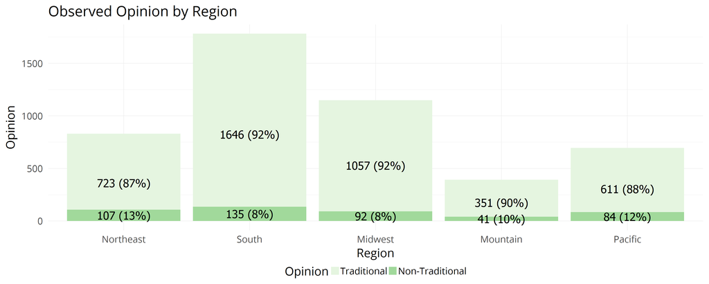

Figure 3: Observed frequencies and proportions

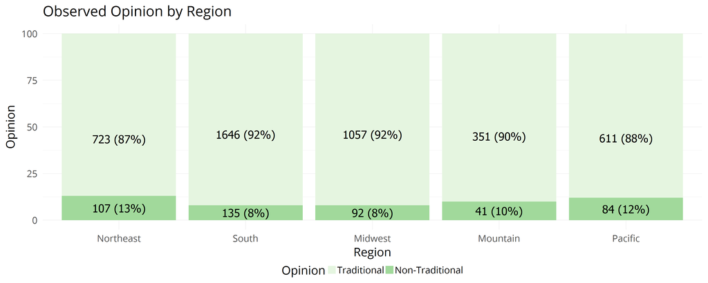

Figure 4: Observed frequencies and proportions

Expected frequencies (Table 12) and proportions (Table 13) under the null hypothesis of independence between region and opinion were computed and are presented along side the observed counts (Table 14) and proportions (Table 15) below.

Table 14: Observed frequencies of opinion by region

|  | Northeast | South | Midwest | Mountain | Pacific |
| --- | --- | --- | --- | --- | --- |
| Traditional | 723 | 1646 | 1057 | 351 | 611 |
| Non-Traditional | 107 | 135 | 92 | 41 | 84 |

Table 12: Expected frequencies of opinion by region

|  | Northeast | South | Midwest | Mountain | Pacific |
| --- | --- | --- | --- | --- | --- |
| Traditional | 751 | 1612 | 1040 | 355 | 629 |
| Non-Traditional | 79 | 169 | 109 | 37 | 66 |

Table 15: Observed proportions of opinion by region

|  | Northeast | South | Midwest | Mountain | Pacific |
| --- | --- | --- | --- | --- | --- |
| Traditional | 0.871 | 0.924 | 0.92 | 0.895 | 0.879 |
| Non-Traditional | 0.129 | 0.076 | 0.08 | 0.105 | 0.121 |

Table 13: Expected proportions of opinion by region

|  | Northeast | South | Midwest | Mountain | Pacific |
| --- | --- | --- | --- | --- | --- |
| Traditional | 0.905 | 0.905 | 0.905 | 0.905 | 0.905 |
| Non-Traditional | 0.095 | 0.095 | 0.095 | 0.095 | 0.095 |

### Hypotheses

Two sets of hypotheses were tested: hypothesis test for independence and hypothesis test for the difference in proportion of opinion across regions.

#### Independence

With respect to the independence of opinion and region, the following hypotheses were investigated.  
* **Null Hypothesis**: Opinion and geographic region are independent.  
* **Alternative Hypothesis**: Opinion and geographic region are not independent.

Using the observed and expected proportions from Table 15 and Table 13, the hypothesis statements were formalized as follows.  
$H_0$: $p_1 = p_{10}, p_2 = p_{20}, ...p_k = p_{k0}$  
$H_a$: At least one observed proportion is different from the expected proportion

where:  
$k$ is 10, the number of response categories  
$p_k$ is the *observed* proportion for the $k^{th}$ response category  
$p_{k0}$ is the *expected* proportion for the $k^{th}$ response category

#### Difference in Proportions

Similarly, the hypothesis statement for the difference in opinion across regions is stated as follows.  
* **Null Hypothesis**: There is no statistically significant difference in opinion across regions.  
* **Alternative Hypothesis**: A statistically significant difference in the proportions of opinion exists with at least one region.

More formally:  
$H_0$: $p_1 = p_2 = , ..., p_k$  
$H_a$: $H_0$ is not true

where:  
$k$ is 5, the number of regions  
$p_k$ is the *observed* proportion for the $k^{th}$ region

### Inference Conditions

The inference conditions were evaluated as follows:  
1. **Independence:** All cases that contributed counts to the table were independent of all the other cases in the table.  
2. **Success/Failure:** As indicated in Table 12, the observed number of successes (non-traditional opinion) and failures (traditional opinion) met the minimum 10 count threshold across all regions.  
3. **Sample Size:** As shown in Table 12, all *expected* counts exceeded the minimum five-count threshold. Furthermore, the sample was less than 10% of the U.S. adult population.  
4. **Degrees of Freedom:** The contingency tables were associated with a chi-square distribution with 4 degrees of freedom, exceeding the minimum threshold of two degrees of freedom for chi-square testing.

As such, the conditions for parametric inference were met.

### Statistical Method

A chi-square test of independence was used to test for an association between opinion and all levels of the region variable at once. To evaluate the differences in proportion of opinion across regions, multiple difference in proportion tests were performed. Though confidence intervals were provided for the true difference in proportions in the population, no comparison was made between the confidence intervals for the differences and the chi-square hypothesis test.

### Test Results

#### Chi-square Test of Independence

A chi-square test of independence was performed to challenge the null hypothesis that no association exists between opinion, and the explanatory variable, region.

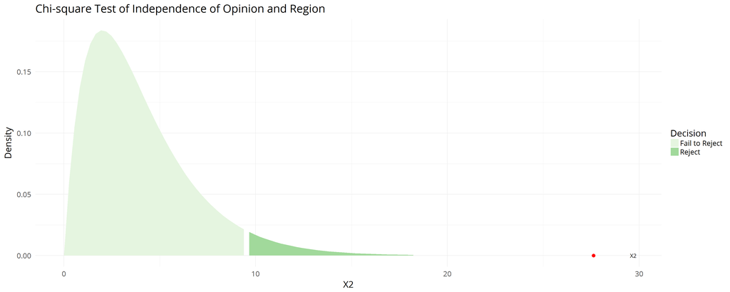

Figure 5: Chi-square test of independence plot  
Table 16: Chi-square test of independence of opinion and region

| Response | Explanatory | d.f. | N | Critical.Value | X.Squared | p.value | Decision |
| --- | --- | --- | --- | --- | --- | --- | --- |
| Opinion | Region | 4 | 4847 | 9.49 | 27.62 | p < 0.05 | Reject |

As shown in Figure 5 and Table 16, the critical value indicated by the shaded region was 9.49. The sum of the squared differences (indicated by the red dot) between observed counts and the expected counts was 28. With 4 degrees of freedom and N = 4,847, the probability of encountering a difference this extreme (p-value) was approximately 0.

Therefore, the null hypothesis was rejected in favor of the alternative hypothesis which states with 95% confidence, that the response variable, opinion, and explanatory variable, region, are not independent.

#### Difference in Proportions Test

Table 17: Difference in proportion tests

| Populations | Contrast | Value | Z-Score | p-value | 95% CI | Significant | Relative Risk |
| --- | --- | --- | --- | --- | --- | --- | --- |
| Northeast - South | p1 - p2 | 0.053 | 4.358 | 0 | [ 0.007, 0.099 ] | Yes | 1.7 |
| Northeast - Midwest | p1 - p3 | 0.049 | 3.565 | 0 | [ 0, 0.098 ] | Yes | 1.61 |
| Northeast - Mountain | p1 - p4 | 0.024 | 1.217 | 0.224 | [ -0.043, 0.092 ] | No | 1.23 |
| Northeast - Pacific | p1 - p5 | 0.008 | 0.473 | 0.636 | [ -0.051, 0.067 ] | No | 1.07 |
| South - Midwest | p2 - p3 | -0.004 | -0.422 | 0.673 | [ -0.04, 0.031 ] | No | 0.95 |
| South - Mountain | p2 - p4 | -0.029 | -1.892 | 0.059 | [ -0.087, 0.029 ] | No | 0.72 |
| South - Pacific | p2 - p5 | -0.045 | -3.548 | 0 | [ -0.093, 0.003 ] | Yes | 0.63 |
| Midwest - Mountain | p3 - p4 | -0.025 | -1.493 | 0.135 | [ -0.085, 0.036 ] | No | 0.77 |
| Midwest - Pacific | p3 - p5 | -0.041 | -2.889 | 0.004 | [ -0.092, 0.01 ] | No | 0.66 |
| Mountain - Pacific | p4 - p5 | -0.016 | -0.807 | 0.419 | [ -0.085, 0.053 ] | No | 0.87 |

As such, opinion was not independent of geographic region.

Table 18: Analysis of opinion by region

| Region | Opinion | PctProp | CumPct | RelativePct |
| --- | --- | --- | --- | --- |
| Northeast | Non-Traditional | 25 | 25 | 126 |
| Pacific | Non-Traditional | 24 | 49 | 118 |
| Mountain | Non-Traditional | 20 | 69 | 102 |
| Midwest | Non-Traditional | 16 | 85 | 78 |
| South | Non-Traditional | 15 | 100 | 74 |

## Research Question 3: Opinion by Class

The aim here was to illuminate any relationship between opinion and class via the following research question.

> Is there an association between opinion and socio-economic class?

### The Data

The observed frequencies and proportions of opinion vis-a-vis class for the years 2012 thru 2016 are presented in the following barplots.

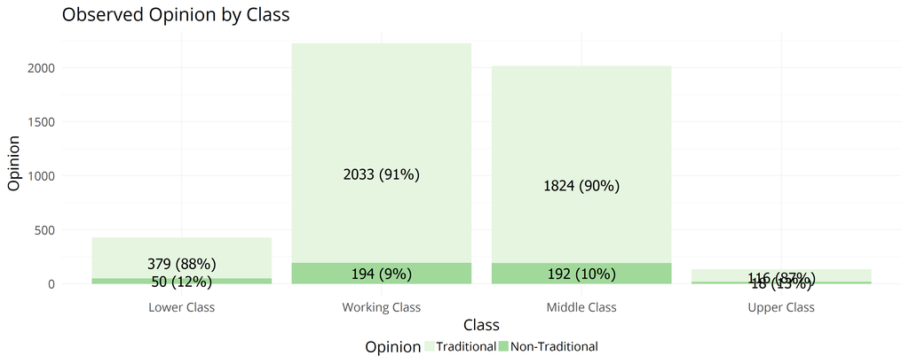

Figure 6: Observed frequencies and proportions

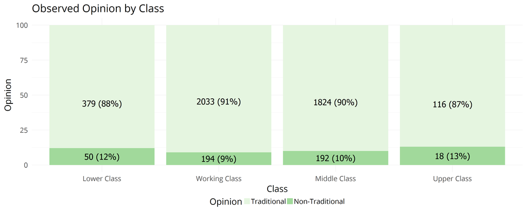

Figure 7: Observed frequencies and proportions

Expected frequencies (Table 19) and proportions (Table 20) under the null hypothesis of independence between class and opinion were computed and are presented along side the observed counts (Table 21) and proportions (Table 22) below.

Table 21: Observed frequencies of opinion by class

|  | Lower Class | Working Class | Middle Class | Upper Class |
| --- | --- | --- | --- | --- |
| Traditional | 379 | 2033 | 1824 | 116 |
| Non-Traditional | 50 | 194 | 192 | 18 |

Table 19: Expected frequencies of opinion by class

|  | Lower Class | Working Class | Middle Class | Upper Class |
| --- | --- | --- | --- | --- |
| Traditional | 388 | 2017 | 1826 | 121 |
| Non-Traditional | 41 | 210 | 190 | 13 |

Table 22: Observed proportions of opinion by class

|  | Lower Class | Working Class | Middle Class | Upper Class |
| --- | --- | --- | --- | --- |
| Traditional | 0.883 | 0.913 | 0.905 | 0.866 |
| Non-Traditional | 0.117 | 0.087 | 0.095 | 0.134 |

Table 20: Expected proportions of opinion by class

|  | Lower Class | Working Class | Middle Class | Upper Class |
| --- | --- | --- | --- | --- |
| Traditional | 0.906 | 0.906 | 0.906 | 0.906 |
| Non-Traditional | 0.094 | 0.094 | 0.094 | 0.094 |

### Hypotheses

Two sets of hypotheses were tested: hypothesis test for independence and hypothesis test for the difference in proportion of opinion across classes.

#### Independence

With respect to the independence of opinion and class, the following hypotheses were investigated.  
* **Null Hypothesis**: Opinion and class are independent.  
* **Alternative Hypothesis**: Opinion and class are not independent.

Using the observed and expected proportions from Table 22 and Table 20, the hypothesis statements were formalized as follows.  
$H_0$: $p_1 = p_{10}, p_2 = p_{20}, ...p_k = p_{k0}$  
$H_a$: At least one observed proportion is different from the expected proportion

where:  
$k$ is 8, the number of response categories  
$p_k$ is the *observed* proportion for the $k^{th}$ response category  
$p_{k0}$ is the *expected* proportion for the $k^{th}$ response category

#### Difference in Proportions

Similarly, the hypothesis statement for the difference in opinion across classes is stated as follows.  
* **Null Hypothesis**: There is no statistically significant difference in opinion across classes.  
* **Alternative Hypothesis**: A statistically significant difference in the proportions of opinion exists with at least one class.

More formally:  
$H_0$: $p_1 = p_2 = , ..., p_k$  
$H_a$: $H_0$ is not true

where:  
$k$ is 4, the number of classes  
$p_k$ is the *observed* proportion for the $k^{th}$ class

### Inference Conditions

The inference conditions were evaluated as follows:  
1. **Independence:** All cases that contributed counts to the table were independent of all the other cases in the table.  
2. **Success/Failure:** As indicated in Table 19, the observed number of successes (non-traditional opinion) and failures (traditional opinion) met the minimum 10 count threshold across all classes.  
3. **Sample Size:** As shown in Table 19, all *expected* counts exceeded the minimum five-count threshold. Furthermore, the sample was less than 10% of the U.S. adult population.  
4. **Degrees of Freedom:** The contingency tables were associated with a chi-square distribution with 3 degrees of freedom, exceeding the minimum threshold of two degrees of freedom for chi-square testing.

As such, the conditions for parametric inference were met.

### Statistical Method

A chi-square test of independence was used to test for an association between opinion and all levels of the class variable at once. To evaluate the differences in proportion of opinion across classes, multiple difference in proportion tests were performed. Though confidence intervals were provided for the true difference in proportions in the population, no comparison was made between the confidence intervals for the differences and the chi-square hypothesis test.

### Test Results

#### Chi-square Test of Independence

A chi-square test of independence was performed to challenge the null hypothesis that no association exists between opinion, and the explanatory variable, class.

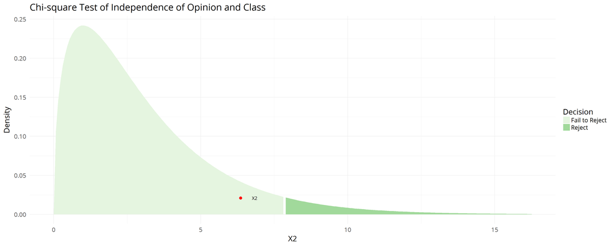

Figure 8: Chi-square test of independence plot  
Table 23: Chi-square test of independence of opinion and class

| Response | Explanatory | d.f. | N | Critical.Value | X.Squared | p.value | Decision |
| --- | --- | --- | --- | --- | --- | --- | --- |
| Opinion | Class | 3 | 4806 | 7.81 | 6.36 | 0.1 | Fail to Reject |

As shown in Figure 8 and Table 23, the critical value indicated by the shaded region was 7.81. The sum of the squared differences (indicated by the red dot) between observed counts and the expected counts was 6. With 3 degrees of freedom and N = 4,806, the probability of encountering a difference this extreme (p-value) was approximately 0.095.

Therefore, the null hypothesis that no association exists between response variable opinion and explanatory variable class was not rejected.

#### Difference in Proportions Test

To confirm, pairwise difference in proportion tests were conducted with the Bonferroni correction. As indicated in Table 24, there were no significant differences in the proportions of opinion between the classes.

Table 24: Difference in proportion tests

| Populations | Contrast | Value | Z-Score | p-value | 95% CI | Significant | Relative Risk |
| --- | --- | --- | --- | --- | --- | --- | --- |
| Lower Class - Working Class | p1 - p2 | 0.029 | 1.933 | 0.053 | [ -0.024, 0.083 ] | No | 1.34 |
| Lower Class - Middle Class | p1 - p3 | 0.021 | 1.342 | 0.18 | [ -0.032, 0.075 ] | No | 1.22 |
| Lower Class - Upper Class | p1 - p4 | -0.018 | -0.551 | 0.581 | [ -0.124, 0.089 ] | No | 0.87 |
| Working Class - Middle Class | p2 - p3 | -0.008 | -0.919 | 0.358 | [ -0.036, 0.02 ] | No | 0.91 |
| Working Class - Upper Class | p2 - p4 | -0.047 | -1.857 | 0.063 | [ -0.143, 0.049 ] | No | 0.65 |
| Middle Class - Upper Class | p3 - p4 | -0.039 | -1.476 | 0.14 | [ -0.136, 0.057 ] | No | 0.71 |

Therefore, opinion w.r.t. extra-marital conduct was independent of class.

## Research Question 4: Opinion by Gender

The aim here was to illuminate any relationship between opinion and gender via the following research question.

> Is there an association between opinion and gender?

### The Data

The observed frequencies and proportions of opinion vis-a-vis gender for the years 2012 thru 2016 are presented in the following barplots.

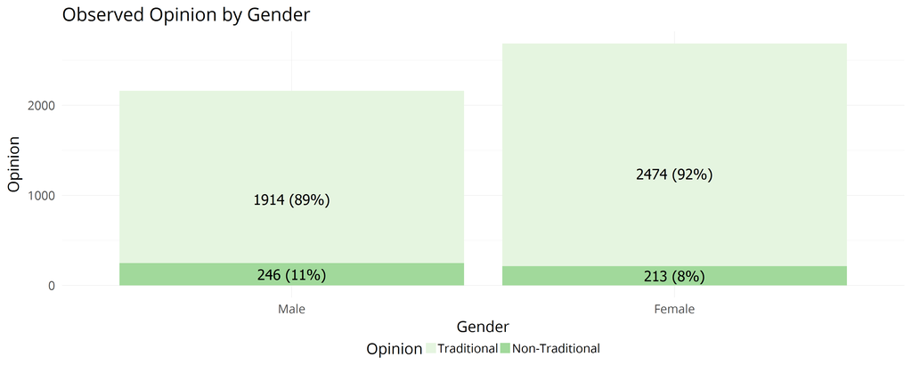

Figure 9: Observed frequencies and proportions

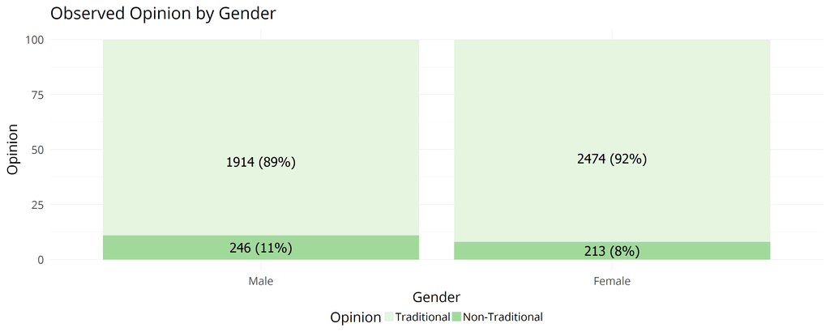

Figure 10: Observed frequencies and proportions

Expected frequencies (Table 25) and proportions (Table 26) under the null hypothesis of independence between gender and opinion were computed and are presented along side the observed counts (Table 27) and proportions (Table 28) below.

Table 27: Observed frequencies of opinion by gender

|  | Male | Female |
| --- | --- | --- |
| Traditional | 1914 | 2474 |
| Non-Traditional | 246 | 213 |

Table 25: Expected frequencies of opinion by gender

|  | Male | Female |
| --- | --- | --- |
| Traditional | 1955 | 2433 |
| Non-Traditional | 205 | 254 |

Table 28: Observed proportions of opinion by gender

|  | Male | Female |
| --- | --- | --- |
| Traditional | 0.886 | 0.921 |
| Non-Traditional | 0.114 | 0.079 |

Table 26: Expected proportions of opinion by gender

|  | Male | Female |
| --- | --- | --- |
| Traditional | 0.905 | 0.905 |
| Non-Traditional | 0.095 | 0.095 |

### Hypotheses

With respect to the independence of opinion and gender, the following hypotheses were investigated.  
* **Null Hypothesis**: Opinion and gender are independent.  
* **Alternative Hypothesis**: Opinion and gender are not independent.

Using the observed and expected proportions from Table 28 and Table 26, the hypothesis statements were formalized as follows.  
$H_0$: $p_1 = p_{10}, p_2 = p_{20}$  
$H_a$: At least one observed proportion is different from the expected proportion

where:  
$p_{1}$ is the *observed* proportion of opinion for men.  
$p_{10}$ is the *expected* proportion of opinion for men.  
$p_{2}$ is the *observed* proportion of opinion for women.  
$p_{20}$ is the *expected* proportion of opinion for women.

### Inference Conditions

The inference conditions were evaluated as follows:  
1. **Independence:** All cases that contributed counts to the table were independent of all the other cases in the table.  
2. **Success/Failure:** As indicated in Table 25, the observed number of successes (non-traditional opinion) and failures (traditional opinion) met the minimum 10 count threshold across all genders.

As such, the conditions for parametric inference were met.

### Statistical Method

To test the association between opinion and gender, the difference in proportion of opinion between genders was computed with p-values and 95% confidence intervals for the true differences in opinion. The results of both the hypothesis test and confidence interval approaches were compared for agreement.

### Test Results

This was a 95% confidence, two-proportion z-test of the null hypothesis that the true population proportion of non-traditional opinion for Male and Female populations are equal.

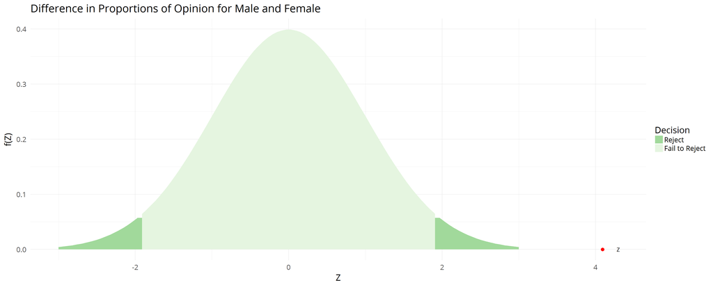

Figure 11: Z-test for difference in proportion of opinion by gender  
Table 29: Z-test for difference in proportion of opinion by gender

| Populations | Contrast | Value | Z-Score | p-value | 95% CI | Significant | Relative Risk |
| --- | --- | --- | --- | --- | --- | --- | --- |
| Male - Female | p1 - p2 | 0.035 | 4.091 | 0 | [ 0.018, 0.051 ] | Yes | 1.44 |

As indicated in Figure 11 and Table 29, the observed difference in the proportion of non-traditional opinion between the Male and Female respondents was 0.035, raising a z-score of 4.091, as indicated by the red dot on the plot. The probability of encountering a difference in proportions this extreme (p-value) was approximately 0, which is less than the probability of incorrectly rejecting the null hypothesis. Further, the confidence interval for the difference in proportions does not include zero, the null hypothesis value, suggesting that a zero difference in non-traditional opinion between the groups is outside the 5% margin of error.

The results of the p-value and confidence interval approaches agree. The null hypothesis was rejected with a 95% confidence, in favor of the alternative hypothesis that the true population proportion of non-traditional opinion within the Male population is not equal to the true proportion of non-traditional opinion in the Female population.

Men in the United States from 2012-2016 were 44% more likely to believe that extra-marital conduct was sometimes wrong or not wrong at all.

## Research Question 5: Opinion by Age

The aim here was to illuminate any relationship between opinion and age via the following research question.

> Is there an association between opinion and age?

### The Data

The observed frequencies and proportions of opinion vis-a-vis age for the years 2012 thru 2016 for the years 2012 thru 2016 are presented in the following barplots.

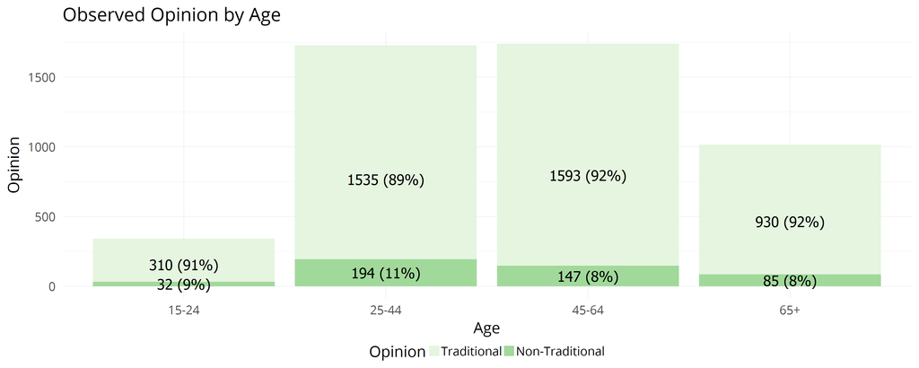

Figure 12: Observed frequencies and proportions

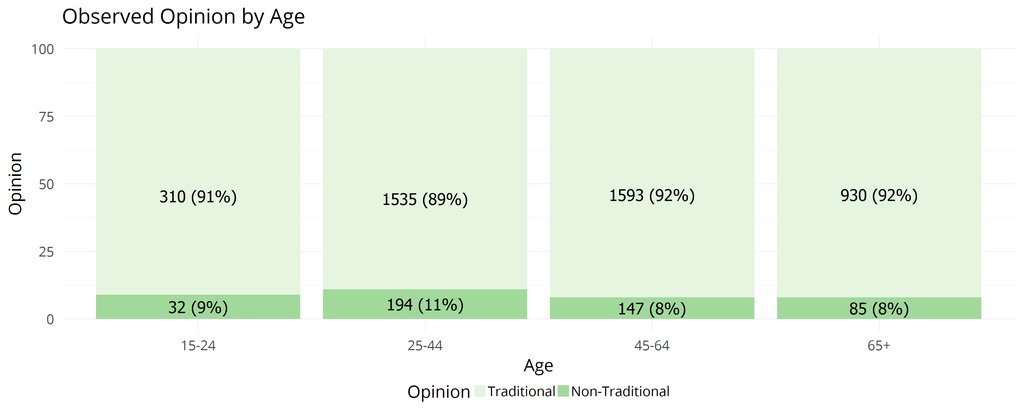

Figure 13: Observed frequencies and proportions

Expected frequencies (Table 30) and proportions (Table 31) under the null hypothesis of independence between age and opinion were computed and are presented along side the observed counts (Table 32) and proportions (Table 33) below.

Table 32: Observed frequencies of opinion by age

|  | 15-24 | 25-44 | 45-64 | 65+ |
| --- | --- | --- | --- | --- |
| Traditional | 310 | 1535 | 1593 | 930 |
| Non-Traditional | 32 | 194 | 147 | 85 |

Table 30: Expected frequencies of opinion by age

|  | 15-24 | 25-44 | 45-64 | 65+ |
| --- | --- | --- | --- | --- |
| Traditional | 310 | 1565 | 1575 | 919 |
| Non-Traditional | 32 | 164 | 165 | 96 |

Table 33: Observed proportions of opinion by age

|  | 15-24 | 25-44 | 45-64 | 65+ |
| --- | --- | --- | --- | --- |
| Traditional | 0.906 | 0.888 | 0.916 | 0.916 |
| Non-Traditional | 0.094 | 0.112 | 0.084 | 0.084 |

Table 31: Expected proportions of opinion by age

|  | 15-24 | 25-44 | 45-64 | 65+ |
| --- | --- | --- | --- | --- |
| Traditional | 0.905 | 0.905 | 0.905 | 0.905 |
| Non-Traditional | 0.095 | 0.095 | 0.095 | 0.095 |

### Hypotheses

Two sets of hypotheses were tested: hypothesis test for independence and hypothesis test for the difference in proportion of opinion across ages.

#### Independence

With respect to the independence of opinion and age, the following hypotheses were investigated.  
* **Null Hypothesis**: Opinion and age are independent.  
* **Alternative Hypothesis**: Opinion and age are not independent.

Using the observed and expected proportions from Table 33 and Table 31, the hypothesis statements were formalized as follows.  
$H_0$: $p_1 = p_{10}, p_2 = p_{20}, ...p_k = p_{k0}$  
$H_a$: At least one observed proportion is different from the expected proportion

where:  
$k$ is 8, the number of response categories  
$p_k$ is the *observed* proportion for the $k^{th}$ response category  
$p_{k0}$ is the *expected* proportion for the $k^{th}$ response category

#### Difference in Proportions

Similarly, the hypothesis statement for the difference in opinion across ages is stated as follows.  
* **Null Hypothesis**: There is no statistically significant difference in opinion across ages.  
* **Alternative Hypothesis**: A statistically significant difference in the proportions of opinion exists with at least one age.

More formally:  
$H_0$: $p_1 = p_2 = , ..., p_k$  
$H_a$: $H_0$ is not true

where:  
$k$ is 4, the number of ages  
$p_k$ is the *observed* proportion for the $k^{th}$ age

### Inference Conditions

The inference conditions were evaluated as follows:  
1. **Independence:** All cases that contributed counts to the table were independent of all the other cases in the table.  
2. **Success/Failure:** As indicated in Table 30, the observed number of successes (non-traditional opinion) and failures (traditional opinion) met the minimum 10 count threshold across all ages.  
3. **Sample Size:** As shown in Table 30, all *expected* counts exceeded the minimum five-count threshold. Furthermore, the sample was less than 10% of the U.S. adult population.  
4. **Degrees of Freedom:** The contingency tables were associated with a chi-square distribution with 3 degrees of freedom, exceeding the minimum threshold of two degrees of freedom for chi-square testing.

As such, the conditions for parametric inference were met.

### Statistical Method

A chi-square test of independence was used to test for an association between opinion and all levels of the age variable at once. To evaluate the differences in proportion of opinion across ages, multiple difference in proportion tests were performed. Though confidence intervals were provided for the true difference in proportions in the population, no comparison was made between the confidence intervals for the differences and the chi-square hypothesis test.

### Test Results

#### Chi-square Test of Independence

A chi-square test of independence was performed to challenge the null hypothesis that no association exists between opinion, and the explanatory variable, age.

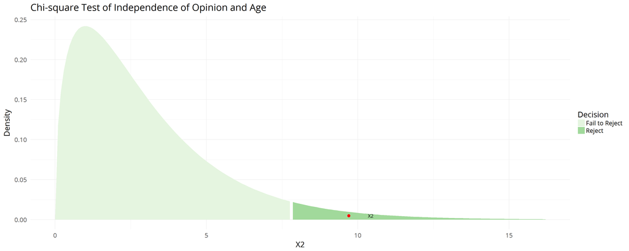

Figure 14: Chi-square test of independence plot  
Table 34: Chi-square test of independence of opinion and age

| Response | Explanatory | d.f. | N | Critical.Value | X.Squared | p.value | Decision |
| --- | --- | --- | --- | --- | --- | --- | --- |
| Opinion | Age | 3 | 4826 | 7.81 | 9.7 | p < 0.05 | Reject |

As shown in Figure 14 and Table 34, the critical value indicated by the shaded region was 7.81. The sum of the squared differences (indicated by the red dot) between observed counts and the expected counts was 10. With 3 degrees of freedom and N = 4,826, the probability of encountering a difference this extreme (p-value) was approximately 0.021.

Therefore, the null hypothesis was rejected in favor of the alternative hypothesis which states with 95% confidence, that the response variable, opinion, and explanatory variable, age, are not independent.

#### Difference in Proportions Test

Pairwise difference in proportion tests were conducted with the Bonferroni correction.

Table 35: Difference in proportion tests

| Populations | Contrast | Value | Z-Score | p-value | 95% CI | Significant | Relative Risk |
| --- | --- | --- | --- | --- | --- | --- | --- |
| 15-24 - 25-44 | p1 - p2 | -0.019 | -1.01 | 0.313 | [ -0.075, 0.037 ] | No | 0.83 |
| 15-24 - 45-64 | p1 - p3 | 0.009 | 0.548 | 0.584 | [ -0.046, 0.064 ] | No | 1.11 |
| 15-24 - 65+ | p1 - p4 | 0.01 | 0.56 | 0.576 | [ -0.048, 0.067 ] | No | 1.12 |
| 25-44 - 45-64 | p2 - p3 | 0.028 | 2.742 | 0.006 | [ -0.005, 0.06 ] | No | 1.33 |
| 25-44 - 65+ | p2 - p4 | 0.028 | 2.381 | 0.017 | [ -0.008, 0.065 ] | No | 1.34 |
| 45-64 - 65+ | p3 - p4 | 0.001 | 0.067 | 0.946 | [ -0.034, 0.036 ] | No | 1.01 |

That said, the results of the chi-square test were considered more reliable and therefore, the conclusion was that opinion was not independent of age.

## Research Question 6: Opinion by Marital Status

The aim here was to illuminate any relationship between opinion and marital status status via the following research question.

> Is there an association between opinion and marital status status?

### The Data

The observed frequencies and proportions of opinion vis-a-vis marital status for the years 2012 thru 2016 for the years 2012 thru 2016 are presented in the following barplots.

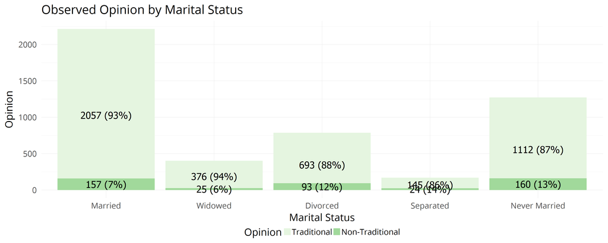

Figure 15: Observed frequencies and proportions

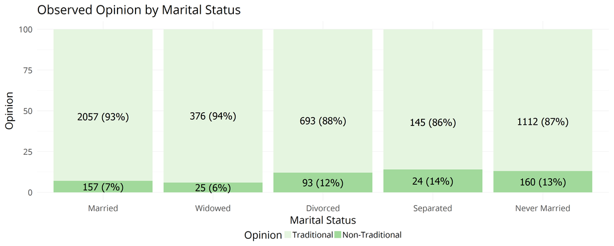

Figure 16: Observed frequencies and proportions

Expected frequencies (Table 36) and proportions (Table 37) under the null hypothesis of independence between marital status and opinion were computed and are presented along side the observed counts (Table 38) and proportions (Table 39) below.

Table 38: Observed frequencies of opinion by marital status

|  | Married | Widowed | Divorced | Separated | Never Married |
| --- | --- | --- | --- | --- | --- |
| Traditional | 2057 | 376 | 693 | 145 | 1112 |
| Non-Traditional | 157 | 25 | 93 | 24 | 160 |

Table 36: Expected frequencies of opinion by marital status

|  | Married | Widowed | Divorced | Separated | Never Married |
| --- | --- | --- | --- | --- | --- |
| Traditional | 2004 | 363 | 711 | 153 | 1151 |
| Non-Traditional | 210 | 38 | 75 | 16 | 121 |

Table 39: Observed proportions of opinion by marital status

|  | Married | Widowed | Divorced | Separated | Never Married |
| --- | --- | --- | --- | --- | --- |
| Traditional | 0.929 | 0.938 | 0.882 | 0.858 | 0.874 |
| Non-Traditional | 0.071 | 0.062 | 0.118 | 0.142 | 0.126 |

Table 37: Expected proportions of opinion by marital status

|  | Married | Widowed | Divorced | Separated | Never Married |
| --- | --- | --- | --- | --- | --- |
| Traditional | 0.905 | 0.905 | 0.905 | 0.905 | 0.905 |
| Non-Traditional | 0.095 | 0.095 | 0.095 | 0.095 | 0.095 |

### Hypotheses

Two sets of hypotheses were tested: hypothesis test for independence and hypothesis test for the difference in proportion of opinion by marital status.

#### Independence

With respect to the independence of opinion and marital status, the following hypotheses were investigated.  
* **Null Hypothesis**: Opinion and marital status status are independent.  
* **Alternative Hypothesis**: Opinion and marital status status are not independent.

Using the observed and expected proportions from Table 39 and Table 37, the hypothesis statements were formalized as follows.  
$H_0$: $p_1 = p_{10}, p_2 = p_{20}, ...p_k = p_{k0}$  
$H_a$: At least one observed proportion is different from the expected proportion

where:  
$k$ is 10, the number of response categories  
$p_k$ is the *observed* proportion for the $k^{th}$ response category  
$p_{k0}$ is the *expected* proportion for the $k^{th}$ response category

#### Difference in Proportions

Similarly, the hypothesis statement for the difference in opinion by marital status is stated as follows.  
* **Null Hypothesis**: There is no statistically significant difference in opinion by marital status.  
* **Alternative Hypothesis**: A statistically significant difference in the proportions of opinion exists with at least one group.

More formally:  
$H_0$: $p_1 = p_2 = , ..., p_k$  
$H_a$: $H_0$ is not true

where:  
$k$ is 5, the number of marital status’  
$p_k$ is the *observed* proportion for the $k^{th}$ marital status

### Inference Conditions

The inference conditions were evaluated as follows:  
1. **Independence:** All cases that contributed counts to the table were independent of all the other cases in the table.  
2. **Success/Failure:** As indicated in Table 36, the observed number of successes (non-traditional opinion) and failures (traditional opinion) met the minimum 10 count threshold across all marital status’.  
3. **Sample Size:** As shown in Table 36, all *expected* counts exceeded the minimum five-count threshold. Furthermore, the sample was less than 10% of the U.S. adult population.  
4. **Degrees of Freedom:** The contingency tables were associated with a chi-square distribution with 4 degrees of freedom, exceeding the minimum threshold of two degrees of freedom for chi-square testing.

As such, the conditions for parametric inference were met.

### Statistical Method

A chi-square test of independence was used to test for an association between opinion and all levels of the marital status variable at once. To evaluate the differences in proportion of opinion by marital status, multiple difference in proportion tests were performed. Though confidence intervals were provided for the true difference in proportions in the population, no comparison was made between the confidence intervals for the differences and the chi-square hypothesis test.

### Test Results

#### Chi-square Test of Independence

A chi-square test of independence was performed to challenge the null hypothesis that no association exists between opinion, and the explanatory variable, marital status.

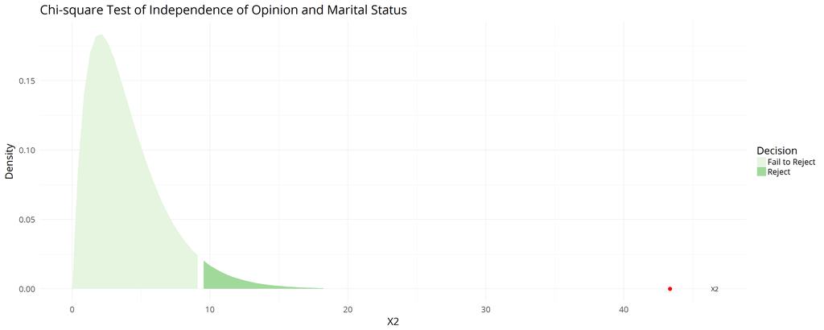

Figure 17: Chi-square test of independence plot  
Table 40: Chi-square test of independence of opinion and marital status

| Response | Explanatory | d.f. | N | Critical.Value | X.Squared | p.value | Decision |
| --- | --- | --- | --- | --- | --- | --- | --- |
| Opinion | Marital Status | 4 | 4842 | 9.49 | 43.34 | p < 0.05 | Reject |

As shown in Figure 17 and Table 40, the critical value indicated by the shaded region was 9.49. The sum of the squared differences (indicated by the red dot) between observed counts and the expected counts was 43. With 4 degrees of freedom and N = 4,842, the probability of encountering a difference this extreme (p-value) was approximately 0.

Therefore, the null hypothesis was rejected in favor of the alternative hypothesis which states with 95% confidence, that the response variable, opinion, and explanatory variable, marital status, are not independent.

#### Difference in Proportions Test

Pairwise difference in proportion tests were conducted with the Bonferroni correction. Significant differences in the proportions of opinion were observed between married and widowed respondents and everyone else. These groups were decidedly more likely than the others to hold traditional views w.r.t. extra-marital conduct.

Table 41: Difference in proportion tests

| Populations | Contrast | Value | Z-Score | p-value | 95% CI | Significant | Relative Risk |
| --- | --- | --- | --- | --- | --- | --- | --- |
| Married - Widowed | p1 - p2 | 0.009 | 0.62 | 0.535 | [ -0.038, 0.055 ] | No | 1.14 |
| Married - Divorced | p1 - p3 | -0.047 | -4.131 | 0 | [ -0.092, -0.003 ] | Yes | 0.6 |
| Married - Separated | p1 - p4 | -0.071 | -3.363 | 0.001 | [ -0.166, 0.024 ] | Yes | 0.5 |
| Married - Never Married | p1 - p5 | -0.055 | -5.425 | 0 | [ -0.092, -0.017 ] | Yes | 0.56 |
| Widowed - Divorced | p2 - p3 | -0.056 | -3.048 | 0.002 | [ -0.114, 0.002 ] | Yes | 0.53 |
| Widowed - Separated | p2 - p4 | -0.08 | -3.099 | 0.002 | [ -0.182, 0.023 ] | Yes | 0.44 |
| Widowed - Never Married | p2 - p5 | -0.063 | -3.532 | 0 | [ -0.116, -0.01 ] | Yes | 0.5 |
| Divorced - Separated | p3 - p4 | -0.024 | -0.852 | 0.394 | [ -0.125, 0.078 ] | No | 0.83 |
| Divorced - Never Married | p3 - p5 | -0.007 | -0.501 | 0.616 | [ -0.059, 0.044 ] | No | 0.94 |
| Separated - Never Married | p4 - p5 | 0.016 | 0.594 | 0.553 | [ -0.083, 0.115 ] | No | 1.13 |

Differences in proportion of opinion, as indicated in Table 41, were significant across most comparisons. The largest differences were among those who were married or widowed and those who were separated.

Table 42: Analysis of opinion by marital status

| Opinion | Marital Status | value | posProp | posFreq | PctProp | CumPct | RelativePct |
| --- | --- | --- | --- | --- | --- | --- | --- |
| Non-Traditional | Separated | 24 | 7 | 12 | 27 | 27 | 137 |
| Non-Traditional | Never Married | 160 | 6 | 80 | 24 | 52 | 121 |
| Non-Traditional | Divorced | 93 | 6 | 46 | 23 | 74 | 114 |
| Non-Traditional | Married | 157 | 4 | 78 | 14 | 88 | 68 |
| Non-Traditional | Widowed | 25 | 3 | 12 | 12 | 100 | 60 |

# Discussion

Researchers, academics, and the media posit that we are amidst a major shift in attitudes and behaviors with respect to marriage. Increasing prevalence of open marriages, consensual non-monogamy (CNM) arrangements, and poly-amorous relationships evidence a challenge towards attitudes of marriage and monogamy. This study sought to explore the evolution and nature of opinion with respect to extra-marital sex by first, examining opinions and how they have changed over time, then by exploring the nature of opinion by gender, class, marital status, age, and geographic region. Opinions were characterized as *traditional* if extra-marital sex was considered to be always or almost always wrong, and *non-traditional* if such behavior was considered sometimes wrong, or not wrong at all.

## Key Findings

The results of the study are summarized in Table 43 below.

Table 43: Summary of Results

| # | Research.Question | Result |
| --- | --- | --- |
| 1 | Is there a linear trend in the proportion of non-traditional opinion over time, controlling for gender? | Yes |
| 2 | Is there an association between opinion w.r.t. extra marital conduct and region? | Yes |
| 3 | Is there an association between opinion w.r.t. extra marital conduct and class? | No |
| 4 | Is there an association between opinion w.r.t. extra marital conduct and gender? | Yes |
| 5 | Is there an association between opinion w.r.t. extra marital conduct and age? | Yes |
| 6 | Is there an association between opinion w.r.t. extra marital conduct and marital status? | Yes |

## Insights and Implications

In 2002, this trend appears to have reversed, as a new generation came of age, and has continued through the present day. The dramatic increase in the proportion of non-traditional opinion observed over the past five years conflates with existing research which cites a dramatic shift in the way in which marriage as in institution, is now being conceived.

**Opinion by Region**  
Geography is a significant indicator of views and opinions with respect to extra-marital conduct. It came as no surprise that the greatest proportion of non-traditional opinion existed in the Northeast and Pacific regions. Similarly, the South appears to hold the most traditional views and the Midwest and Mountain regions represent the moderate range.

**Opinion by Class**  
The lack of significance of class as an indicator of opinion was somewhat of a surprise. Greater affluence (and economic freedom) did not bring significantly more liberal opinion on the matter as was expected.

**Opinion by Age**  
The greatest proportion of non-traditional opinion among the 25-44 age group vis-a-vis the relatively more conservative views of the 45 and over age groups could reflect the generational shift in opinion that has been cited amongst researchers and the media. It would also be reasonable to assume that the number of married years would correlate positively with age, and that opinions may become more conservative among those in longer marriages. Further research could examine the degree to which marital status, length of marriage, and age affect opinion.

**Opinion by Marital Status** The most conservative opinions, not surprisingly, were among the married and widowed groups. Similarly expected, separated people were, on average, 37% more likely to have non-traditional opinions. Their opinion might indicate more about their marital status than the other way around.

# Conclusion

Amid the growing amount of research citing a dramatic shift in the marriage institution, one characterized by increasing acceptance of same-sex marriage, open marriages, and consensual non-monogamy (CNM) arrangements, I sought to investigate the degree to which this shift would be evinced by available data. More specifically, I focused on understanding the nature and evolution of a single aspect of marriage: opinions vis-a-vis fidelity.

**Evolution of Opinion**  
That said, a shift in beliefs and opinions w.r.t. extra-marital conduct is definitely extant in the data. From the early 70’s until about 2002, the trend was towards increasingly conservative thought and opinion, perhaps a natural retraction or readjustment following the sexual revolution of the 60’s and 70’s. However, 2002 and 2012 mark inflection points of shifting opinions and attitudes regarding extra-marital conduct. From 2012-2016 the proportion of non-traditional opinion increased by 42%. The most significant increase was among women where the proportion of non-traditional opinion grew 51% from 0.06 in 2012 to 0.1 in 2016. This conflates with the coming of age of a new generation characterized by diminished deference for marriage as an institution, increasing acceptance of same-sex marriage, and the (re) emergence of open marriages, consensual non-monogamy relationships and the like.

A dramatic shift in marriage as an institution is afoot. Expectations of marriage “until death do us part” are changing and increasing numbers of men and woman admit to having had extra-marital affairs. Social networks have dramatically shifted the scope, range, frequency, and opportunity for interaction. All these factors conflate to produce the phenomena responsible for much of the societal changes we observe. Future studies might explore the factors, such as social networks, that (re)shape our deference for an belief in many of our institutions.

# Appendix

## Source Code

Given the size of the code base for this report, only the select functions responsible for statistical computation were included in the report. This report, along with the software and data are available as part of the xms package which is available for forking at https://github.com/DataScienceSalon/xms. Alternatively, the package can be installed from github using devtools as follows:

```r
devtools::install_github("DataScienceSalon/xms")
```

### Difference in Proportions

The following function performs the repeated difference in proportions tests for multiple proportions.

```r
diffTest <- function(data, alternative = "two.sided", success,
    conf = 0.95, alpha = 0.05) {

    freqDf <- as.data.frame(addmargins(table(data), 1))
    groups <- as.character(unique(freqDf %>% .[[2]]))
    nGroups <- length(groups)

    # Bonferroni Correction for Multiple Groups
    numTests <- nGroups * (nGroups - 1)/2
    alpha <- alpha/numTests

    # Compute critical value
    area <- ifelse(alternative == "two.sided", alpha/2, alpha)
    zAlpha <- qnorm(area, lower.tail = FALSE)

    # Initialize variables
    Populations = Contrast = Value = `Z-Score` = c()
    `p-value` = `95% CI` = Significant = `Relative Risk` = c()
    statements <- list()
    plots <- list()
    k <- 1

    for (i in 1:(nGroups - 1)) {
        for (j in (i + 1):nGroups) {

            #-----------------------------------------------------------------------#
            # Perform Tests #
            #-----------------------------------------------------------------------#
            # Compute prop.test
            successes <- c(as.numeric(freqDf %>% filter(.[[1]] ==
                success & .[[2]] == groups[i]) %>% select(Freq)),
                as.numeric(freqDf %>% filter(.[[1]] == success &
                  .[[2]] == groups[j]) %>% select(Freq)))
            totals <- c(as.numeric(freqDf %>% filter(.[[1]] ==
                "Sum" & .[[2]] == groups[i]) %>% select(Freq)),
                as.numeric(freqDf %>% filter(.[[1]] == "Sum" &
                  .[[2]] == groups[j]) %>% select(Freq)))
            t <- prop.test(successes, totals, correct = FALSE,
                alternative = alternative, conf.level = (1 -
                  (alpha/numTests)))  # Bonferroni Correction

            # Compute z-score
            pPooled <- sum(successes)/sum(totals)
            sePooled <- sqrt((pPooled * (1 - pPooled)/totals[1]) +
                (pPooled * (1 - pPooled)/totals[2]))
            zScore <- ((successes[1]/totals[1]) - (successes[2]/totals[2]))/sePooled
            pValue <- 2 * pnorm(-abs(zScore))

            # Render decision
            if ((alternative == "two.sided" & pValue < (alpha/2)) |
                (alternative != "two.sided" & pValue < alpha)) {
                decision <- "Reject"
            } else {
                decision <- "Fail to Reject"
            }

            # Compute Relative Risk Ratio
            r1 <- successes[1]/totals[1]
            r2 <- successes[2]/totals[2]
            rr <- r1/r2

            #-----------------------------------------------------------------------#
            # Format Results #
            #-----------------------------------------------------------------------#
            Populations[k] <- paste0(groups[i], " - ", groups[j])
            Contrast[k] <- paste0("p", i, " - p", j)
            Value[k] <- as.numeric(round(t$estimate[1] - t$estimate[2],
                3))
            `Z-Score`[k] <- round(zScore, 3)
            `p-value`[k] <- round(t$p.value, 3)
            `95% CI`[k] <- paste0("[ ", round(t$conf.int[1],
                3), ", ", round(t$conf.int[2], 3), " ]")
            Significant[k] <- ifelse(decision == "Reject", "Yes",
                "No")
            `Relative Risk`[k] <- round(rr, 2)

            #-----------------------------------------------------------------------#
            # Plot Results #
            #-----------------------------------------------------------------------#
            plots[[k]] <- plotDiffTest(x = groups[1], y = groups[2],
                zAlpha, zScore)

            #-----------------------------------------------------------------------#
            # Render Statement #
            #-----------------------------------------------------------------------#
            statements[[k]] <- list()
            alt <- ifelse(alternative == "two.sided", "not equal to",
                ifelse(alternative == "less", "less than", "greater than"))
            type1 <- ifelse(decision == "Reject", "less than",
                "greater than")

            ciNote <- ifelse(decision == "Reject", paste0("Further, the confidence interval for the difference in ",
                "proportions does not include zero, the null ",
                "hypothesis value, suggesting that a zero difference ",
                "in ", tolower(success), " opinion between the groups ",
                "is outside the ", alpha * 100, "% margin of error.  "),
                paste0("Further, the confidence interval for the difference in ",
                  "proportions includes zero, suggesting that a zero ",
                  "difference in the proportion of ", tolower(success),
                  " opinion is within the ", alpha * 100, "% margin of ",
                  "error.  "))

            statements[[k]]$type <- paste0("This was a ", (conf *
                100), "% confidence, two-proportion z-test ",
                "of the null hypothesis that the true population proportion of ",
                tolower(success), " opinion for ", groups[i],
                " and ", groups[j], " populations are equal.  ")

            if (decision == "Reject") {
                statements[[k]]$conclude <- paste0("The results of the p-value and confidence interval ",
                  "approaches agree. The null hypothesis was ",
                  "rejected with a ", conf * 100, "% confidence, in favor ",
                  "of the alternative hypothesis that the true ",
                  "population proportion of ", tolower(success),
                  " opinion within the ", groups[i], " population is ",
                  alt, " the true proportion of ", tolower(success),
                  " opinion in the ", groups[j], " population. ")
            } else {
                statements[[k]]$conclude <- paste0("The results of the p-value and confidence ",
                  "interval approaches agree. The null ", "hypothesis that the true ",
                  "population proportions of ", tolower(success),
                  " opinion within the ", groups[i], " and ",
                  groups[j], " populations are equal,
                                           was not rejected. ")
            }

            statements[[k]]$detail <- paste0("the observed difference in the proportion of ",
                tolower(success), " opinion between the ", groups[i],
                " and ", groups[j], " respondents was ", as.numeric(round(t$estimate[1] -
                  t$estimate[2], 3)), ", raising a z-score of ",
                round(zScore, 3), ", as indicated by the red dot on the plot. ",
                "The probability of encountering a difference in ",
                "proportions this extreme (p-value) was approximately ",
                round(t$p.value, 3), ", which is ", type1, " the ",
                "probability of incorrectly rejecting the null ",
                "hypothesis.  ", ciNote)

            k <- k + 1
        }
    }

    #---------------------------------------------------------------------------#
    # Compile Results and Return #
    #---------------------------------------------------------------------------#

    df <- as.data.frame(cbind(Populations, Contrast, Value, `Z-Score`,
        `p-value`, `95% CI`, Significant, `Relative Risk`), stringsAsFactors = FALSE)

    res <- list(sig = list(conf = conf, alpha = alpha, zAlpha = zAlpha),
        result = df, statements = statements, plots = plots)

    return(res)
}
```

### Chi-square Test for Independence

The following function performs the chi-square test of independence and reports the analysis.

```r
x2Test <- function(freqTbl, y, x, conf = 0.95, alpha = 0.05) {

    x2 <- chisq.test(freqTbl)

    # Extract Chisq Data
    criticalVal <- qchisq(alpha, x2$parameter, lower.tail = F)

    # Create Table
    table <- data.frame(Response = y, Explanatory = x, d.f. = x2$parameter,
        N = sum(freqTbl), `Critical Value` = qchisq(alpha, x2$parameter,
            lower.tail = F), `X-Squared` = x2$statistic, `p-value` = ifelse(x2$p.value <
            0.05, "p < 0.05", round(x2$p.value, 3)), Decision = ifelse(x2$p.value >=
            alpha, "Fail to Reject", "Reject"), row.names = NULL)

    # Format Statements
    stmt <- list()
    stmt$type <- paste0("A chi-square test of independence was performed to ",
        "challenge the null hypothesis that no association exists ",
        "between ", tolower(y), ", and the explanatory ", "variable, ",
        tolower(x), ". ")

    if (x2$p.value < (alpha)) {
        stmt$conclude <- paste0("Therefore, the null hypothesis was rejected in ",
            "favor of the alternative hypothesis which states ",
            "with ", conf * 100, "% confidence, that the response ",
            "variable, ", tolower(y), ", and explanatory ", "variable, ",
            tolower(x), ", are not independent. ")
    } else {
        stmt$conclude <- paste0("Therefore, the null hypothesis that no association ",
            "exists between response variable ", tolower(y),
            " and explanatory variable ", tolower(x), " was not rejected. ")
    }

    stmt$detail <- paste0("the critical value indicated by the shaded region ",
        "was ", round(criticalVal, 2), ". The sum of ", "the squared differences (indicated by the red dot) ",
        "between observed counts and the expected counts was ",
        round(x2$statistic, 0), ". With ", x2$parameter, " degrees of freedom and N = ",
        table$N, ", the probability of encountering a difference ",
        "this extreme (p-value) was approximately ", round(x2$p.value,
            3), ". ")


    test <- list(sig = list(conf = conf, alpha = alpha), htest = x2,
        result = table, stmt = stmt)
    return(test)
}
```

### Chi-square Trend Test

The following function performs the chi-square trend test.

```r
x2TrendTest <- function(freqTbl, x, y, z, conf = 0.95, alpha = 0.05) {

    propTbl <- prop.table(freqTbl, 2)
    freqTbl <- addmargins(freqTbl, 1)
    x2 <- prop.trend.test(x = as.numeric(freqTbl[2, ]), n = as.numeric(freqTbl[3,
        ]))


    # Compute Critical Value
    criticalVal <- qchisq(alpha, x2$parameter, lower.tail = F)

    # Create Table
    table <- data.frame(Period = paste0(as.numeric(dimnames(freqTbl)$Year[1]),
        "-", as.numeric(dimnames(freqTbl)$Year[length(freqTbl[2,
            ])])), Response = y, Explanatory = x, Gender = z,
        d.f. = x2$parameter, N = sum(freqTbl[3, ]), `Critical Value` = criticalVal,
        `X-Squared` = x2$statistic, `p-value` = ifelse(x2$p.value <
            0.05, "p < 0.05", round(x2$p.value, 3)), Decision = ifelse(x2$p.value >=
            alpha, "Fail to Reject", "Reject"), row.names = NULL)

    # Format Statements
    stmt <- list()
    stmt$type <- paste0("A chi-square test for trend in proportions was ",
        "conductedin order to ", "challenge the null hypothesis that no linear trend exists ",
        "in opinion over time. ")

    if (x2$p.value < (alpha)) {
        stmt$conclude <- paste0("Therefore, the null hypothesis was rejected in ",
            "favor of the alternative hypothesis which states ",
            "with ", conf * 100, "% confidence, that opinion ",
            "changes linearly over time.  ")
    } else {
        stmt$conclude <- paste0("Therefore, the null hypothesis that no linear ",
            "relationship between opinion and time exists, ",
            "was not rejected. ")
    }

    stmt$detail <- paste0("the critical value indicated by the shaded region ",
        "was ", round(criticalVal, 2), ". The sum of ", "the squared differences (indicated by the red dot) ",
        "between observed counts and the expected counts was ",
        round(x2$statistic, 0), ". With ", x2$parameter, " degrees of freedom and N = ",
        table$N, ", the probability of encountering a difference ",
        "this extreme (p-value) was approximately ", round(x2$p.value,
            3), ". ")


    test <- list(sig = list(conf = conf, alpha = alpha), result = table,
        stmt = stmt)
    return(test)
}
```

# References

Avvo. 2017. “New Avvo survey explores modern attitudes around love, sex, and dating - AvvoStories.” Accessed October 27. http://stories.avvo.com/relationships/new-avvo-survey-explores-modern-attitudes-around-love-sex-dating.html.

Baptiste Auguie, Anton Antonov. 2016. “R package gridExtra.” https://cran.r-project.org/web/packages/gridExtra/gridExtra.pdf ftp://cran.r-project.org/pub/R/web/packages/gridExtra/gridExtra.pdf.

Chicago, NORC at the University of. 2017. “GSS Data Explorer | NORC at the University of Chicago.” Accessed September 29. https://gssdataexplorer.norc.org/pages/show?page=gss{\%}2Fabout.

Dahl, Author David B, and Maintainer David Scott. 2016. “Package ‘xtable’.” https://cran.r-project.org/web/packages/xtable/xtable.pdf.

Dowle, Matt. 2016. “Package ‘data.table’.” *Cran*.

Hlavac, Marek, Type Package, Title Well-formatted Regression, and Summary Statistics Tables. 2015. “Well-Formatted Regression and Summary Statistics Tables.” https://cran.r-project.org/web/packages/stargazer/stargazer.pdf.

Johnson, Lee N., Richard B Miller, Angela B. Bradford, and Shayne R. Anderson. 2017. “The Marriage and Family Therapy Practice Research Network (MFT-PRN): Creating a More Perfect Union Between Practice and Research.” *Journal of Marital and Family Therapy* 43 (4): 561–72. doi:10.1111/jmft.12238.

Koohafkan, Michael C. 2015. “Package ’kfigr’ | Integrated Code Chunk Anchoring and Referencing for R Markdown.”

NORC. 2017. “About NORC Menu | NORC.org.” Accessed September 30. http://www.norc.org/About/Pages/default.aspx.

R Core Team. 2013. “The R Stats Package.” doi:Version: 3.4.0.

Rcpp, Linkingto. 2016. “R Package ‘reshape2’.” https://cran.r-project.org/web/packages/reshape2/reshape2.pdf.

Rstudio Team. 2016. “RStudio – Open source and enterprise-ready professional software for R.” https://www.rstudio.com/.

Taylor, Paul. 2010. “The Decline of Marriage And Rise of New Families.” *Pew Research Center*. http://pewsocialtrends.org.

The R Foundation. 2015. “What is R?” doi:10.1016/B978-0-12-417113-8.09994-X.

Wickham, Hadley. 2016. “R Package ’ggplot2’ | Create Elegant Data Visualisations Using the Grammar of Graphics.”

Xie, Yihui. 2013. “knitr: Elegant, flexible and fast dynamic report generation with R | knitr.” http://yihui.name/knitr/ http://yihui.name/knitr/{\%}5Cnpapers2://publication/uuid/21E89689-A1A0-4422-A0C8-45D31FA20C5B.

John James jjames@datasciencesalon.org

01 November, 2017